# STAT 2450 Assignment 3 (40 points)

Tasneem Hoque

Banner: B00841761

## Problem 1 (5 pts)

In this problem, we will manipulate unit conversion formulas. We will assume that:

1 USD = 1.28 CAD 1 american pint = 0.473 liters

An industry standard beer bottle or beer can is 12 U.S. fluid ounces. A U.S. pint is equal to 16 U.S. fluid ounces. In other words, the volume of liquid contained in a bottle of beer is equivalent to 3/4 U.S. pints.

Write a function, named ‘cpl’, that calculates the price of a litre of beer in canadian dollars (CAD), based on the price of a pack of 12 beers in U.S. dollars (USD).

Your function should take two arguments: the number of bottle in a pack of beers (nb) and the cost in USD of this pack of beer (usd). This way, you will be able to use packs of 6 or packs of 12 bottles of beer.

Your function should return the price, in canadian dollars (CAD) per liter of beer.

```r
cpl=function(nb, usd){
  ppb = nb/usd
  vpb = 0.75*0.473
  usdpl = vpb/ppb
  cadpl= usdpl * 1.28
  return(cadpl)
}
```

Now use your function; assume that a pack of 12 beers costs 14.73 USD and let your function display the price in CAD of one liter of beer.

```r
cpl(12,14.73)
```

```
## [1] 0.5573832
```

## Problem 2 (5 points)

In this problem, we want to see if we find a value (root) of x such that:

$$x^3-10x+1=0$$
We will implement a simple version of the so-called bisection method to find intervals that contain a root.

### 2.1 [2 pts]

write a code that creates a grid (vector) ‘x’ of regularly spaced values between $x=-5$ and $x=5$ by steps of $0.01$, and computes a vector ‘y’ of the values of the polynomial at the positions given by x.

Use x and y to plot (as a line, use type=‘l’) the graph of this cubic function. Call the function ‘abline’ three times to overlay one horizontal line at $y=0$, and two vertical lines: a red line at $x=-2$ and a blue line at $x=-4$.

Your plot should clearly show that the graph of the cubic curve crosses the x-axis, $y=0$, somewhere between $x=-4$ and $x=-2$. Observe that this cubic function takes a negative value at $x=-4$ and a positive value at $x=-2$.

```r
x = seq(-5, 5, by = 0.01)
expand.grid(x)
```

[output not shown]

[output cut: 987 more lines]

```r
y <- vector(length=length(x))

for (i in 1:length(x)) {
  y[i] = x[i]^3 - 10*x[i] + 1

}

expand.grid(y)
```

[output not shown]

[output cut: 987 more lines]

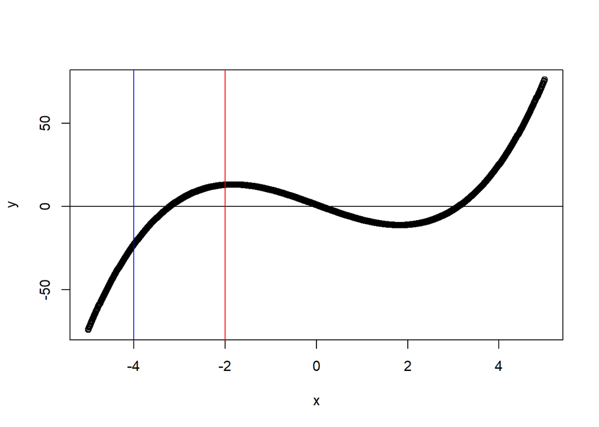

```r
plot(x,y)
abline(h=0)
abline(v=-2, col='red')
abline(v=-4, col='blue')
```

### 2.2 (2 pts)

Write a function called ‘findroot’ that obeys the following prescriptions:

1. the function has 4 arguments: p,q,a,b
2. p and q are the coefficients of a cubic polynomial
   $$f(x)=x^3+px+q$$
   of which we want to find a root (real value of x that makes this expression equal to zero).
3. We want the function to always return the midpoint of the interval $[a,b]$.
4. We want the function to print the message ‘there is a root between a and b’, when the signs that the polynomial function takes at $x=a$ and $x=b$ differ (i.e. $f(a)$ and $f(b)$ have different signs).

Therefore, all you have to do is to calculate the values $f(a)$ and $f(b)$ of the polynomial at each end (a or b) of the interval $[a,b]$, and compute the product of these values. If the product is negative, it means that the signs of the polynomial function differ when calculated at a and at b, which implies that the graph of the polynomial is crossing the x axis (i.e. there is a zero or a root inside the interval [a,b]). If this condition is satisfied, then print the message ‘there is a root between a and b’. otherwise, print no message.

Make sure that your function always returns the midpoint of the interval $[a,b]$, even if no message is printed.

write the function ‘findroot’ here:

```r
findroot=function(p,q,a,b){
  fa = (a)^3+p*(a)+q
  fb = (b)^3+p*(b)+q
  num = fa*fb

  if(num < 0) {
    cat("There is a zero or root inside the interval [",a,",",b,"]\n")
  }
  return((fa+fb)/2)
}
```

### 2.3 (1 pt)

Now, let’s apply your function to the example above. Use your function to answer these questions:

1. is there is a root between -4 and -2 ?

```r
findroot(-10,1,-4,-2)
```

```
## There is a zero or root inside the interval [ -4 , -2 ]
```

```
## [1] -5
```

2. Is there a root between -3.25 and -3.125 ?

```r
findroot(-10,1,-3.25,-3.125)
```

```
## There is a zero or root inside the interval [ -3.25 , -3.125 ]
```

```
## [1] 0.4521484
```

Note: the bisection method is a robust method that can be used to find the roots of any continuous fonction on a compact (finite and closed) interval $[a,b]$. Feel free (THIS IS NOT a question for THIS assignment) to fully implement the bisection algorithm as a fun exercise.

## Problem 3 (5 pts)

When $x_1, x_2, \ldots , x_n$ is a sample from a normal distribution with unknown mean $\mu$ and unknown variance $\sigma^2$, the level $100(1-\alpha)$% confidence interval for $\mu$ is given by the following formula:

$$\bar x \pm t_{1-\alpha/2, n-1}
\frac{s}{\sqrt n}$$

where $\bar x$ and $s$ are the sample mean and sample standard deviation of the data, and $t_{1-\alpha/2, n-1}$ cuts off an area $1-\alpha/2$ to its left under the $t$ curve with $n-1$ degrees of freedom.

Write a function which has two arguments, a vector of data $x$, and alpha, which takes any value between 0 and 1, but should have a default value of .05 (hence you must learn how to program functions with default values for their arguments).

The function should return a vector of length 2, which contains the endpoints of the confidence interval.

The percentiles of the t-distribution can be calculated as follows. Suppose that you want the 97.5’th percentile of the t-distribution with 11 degrees of freedom. This can be calculated in R as

```r
qt(.975,11)
```

```
## [1] 2.200985
```

```r
# write your function
conf = function(x,a=0.05) {
    n= length(x)
    y = vector(length=2)

  meanResult = mean(x)
   stdDev = sd(x)

   tnx <- qt(1-a/2,n-1)
   print(tnx)

   y[1]<-meanResult - tnx*stdDev/sqrt(n)
   y[2]<-meanResult + tnx*stdDev/sqrt(n)

   return(y)
}
```

Test your function by calculating the 98% confidence interval using the following data

```r
set.seed(222)
data=rnorm(25,mean=2.5,sd=.45)
```

When putting your two endpoints together, you may find something similar to the following to be useful.

```r
1+c(-1,1)*.25
```

```
## [1] 0.75 1.25
```

```r
# apply your function to the data sample 'data'

conf(data,0.02)
```

```
## [1] 2.492159
```

```
## [1] 2.248660 2.711667
```

Now check that your calculation is correct, by using:

```r
t.test(data,conf.level=.98)
```

```
##
##  One Sample t-test
##
## data:  data
## t = 26.699, df = 24, p-value < 2.2e-16
## alternative hypothesis: true mean is not equal to 0
## 98 percent confidence interval:
##  2.248660 2.711667
## sample estimates:
## mean of x
##  2.480163
```

## Problem 4 (5 pts)

The derivative of a function $f(x)$ at $x$ can be approximated by the Newton’s quotient

$$\frac{f(x+h) - f(x-h)}{2 *
h}$$

where $h$ is a small number.

Write a function named ‘slope’ to calculate the Newton’s quotient for the function $f(x) = exp(x)$.

The function should take two scalar arguments, $x$ and $h$. Make sure that your function has a default value of $h=1.e-6$.

Test your function at the point $x=1$ using the default value of $h$, and write a line of code to compare approximate value of the derivative calculated by your function to the true (theoretical) value of the derivative of $f(x)=e^x$ at $x=1$, which is $f'(1) = e^1$.

```r
slope = function(x, h = 1.e-6){
   quotient = (exp(x+h) - exp(x-h))/(2*h)
   return(quotient)
}

# call function to find slope
slope(1)
```

```
## [1] 2.718282
```

```r
# test function
x=1
deriv(exp(x), 'x')
```

```
## expression({
##     .value <- 2.71828182845905
##     .grad <- array(0, c(length(.value), 1L), list(NULL, c("x")))
##     .grad[, "x"] <- 0
##     attr(.value, "gradient") <- .grad
##     .value
## })
```

## Problem 5 (10 pts)

A very useful feature in R is the ability to pass a function name as an argument.

Here is an example, where we pass three different function names: $exp(x)$, $log(x)$, and $sin(x)$, to the function ‘test’ to do calculations that depends on the function choice:

```r
test=function(x,a,f){
 output=f(x+a)+f(x-a)
 return(output)
}
test(0,2,exp) # this will calculate exp(0+2)+exp(0-2)
```

```
## [1] 7.524391
```

```r
test(20,5,log) # this will calculate log(20+5)+log(20-5)
```

```
## [1] 5.926926
```

```r
test(0,1,sin) # this will calculate sin(0+1)+sin(0-1)
```

```
## [1] 0
```

### 4.1 (4 pts)

Now, modify the function you wrote for problem 4 so that your new function, called ‘slopef’, accepts a new argument that is the name of a function of which you want to approximate the derivative.

The function ‘slopef’ should also accept an argument named $h$ for the ‘infinitesimal’ step size. Use the same default value as in problem 4 for this argument.

```r
# implement your 'slopef' function here
slopef = function(x,f, h  = 1e-06) {
  output=(f(x+h)-f(x-h))/(2*h)
  return(output)
}
```

### 4.2 (3 pts)

When your function is written, use it to approximate the derivative of sin(x) at $x=\pi/4$, of $log(x)$ at $x=3$, and of $exp(x)$ at $x=2$.

```r
slopef(pi/4,sin)
```

```
## [1] 0.7071068
```

```r
slopef(3,log)
```

```
## [1] 0.3333333
```

```r
slopef(2,exp)
```

```
## [1] 7.389056
```

### 4.3 (3 pts)

Note that you can easily check that your results are right, because we know the analytical expression of the derivatives of the sin, the log and the exp function.

$$\frac{d}{dx} (\sin x) = \cos x \\
\frac{d}{dx} (\log x) = \frac{1}{x} \\ \frac{d}{dx} (e^x) = e^{x} \\$$

Write a code to compute (and print) the 3 values of the derivatives, computed from these analytical expressions

```r
cos(pi/4)
```

```
## [1] 0.7071068
```

```r
1/3
```

```
## [1] 0.3333333
```

```r
exp(2)
```

```
## [1] 7.389056
```

## Problem 6 (10 points)

In this problem, you will need to write a code that estimates the empirical coverage of the student t confidence intervals. To do so, proceed exactly as seen in lecture 1 of Module 3. Feel free to copy, paste and adapt the code contained in the Rmd file of this lecture.

Please write your code so as to conform to the following prescriptions:

Use 20 simulations.

In each simulation, use a new sample of size n=10 Draw your sample from a normal distribution with (‘true’) mean 15 and (‘true’) standard deviation 3.

For your plot, which should show each t-confidence interval as a horizontal segment, use xlim =c(10,20) (for Nbatch simulations, one should see Nbatch confidence interval segments in the plot).

For each simulation, you will use the formula of student to compute a 90% CI, and increment a counter to estimate the empirical coverage.

Write your simulation code:

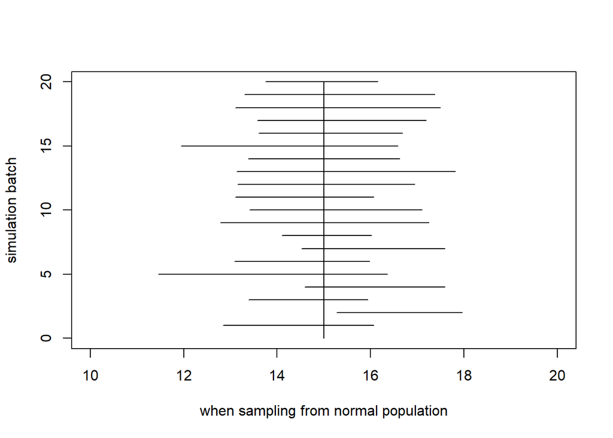

```r
Nbatch=20
plot(0,0,xlim=c(10,20),ylim=c(0,Nbatch),type="n",  ylab="simulation batch", xlab="when sampling from normal population")


 n=10
 truemean=15;
 truesd=3;

 alpha=.1

 cover=0

for (i in 1:Nbatch) {

   data=rnorm(n,truemean,truesd)
   estmean = mean(data)
   estsd   =   sd(data)

   tnx <- qt(1-alpha/2,n-1)

   tint=estmean + c(-1,1)*tnx*estsd/sqrt(n)

   count1=ifelse(tint[1]<truemean&&truemean<tint[2],1,0)

   cover=cover+count1

   lines(tint,c(i,i))

 }

lines(c(truemean,truemean),c(0,Nbatch))
```

```r
 empirical=cover/Nbatch
```

Print the estimate empirical coverage:

```r
 print(paste("empirical coverage is ",100*empirical,"%"))
```

```
## [1] "empirical coverage is  95 %"
```

What does the empirical coverage become when you repeat this exercise, but replace the value n=10 by n=200 AND Nbatch=20 by Nbatch=1000?

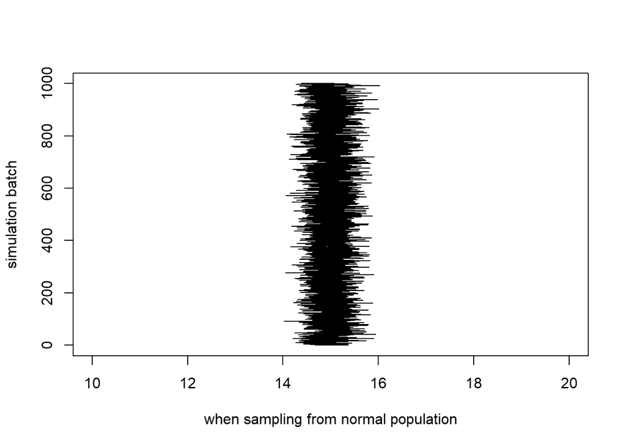

```r
# copy your code above, but replace n=20 by n=200
# and rerun the code
# print the new estimation of the empirical coverage

Nbatch=1000
plot(0,0,xlim=c(10,20),ylim=c(0,Nbatch),type="n",  ylab="simulation batch", xlab="when sampling from normal population")

 n=200

 truemean=15;
 truesd=3;

 alpha=.1

 cover=0

for (i in 1:Nbatch){

   data=rnorm(n,truemean,truesd)

   estmean = mean(data)
   estsd   =   sd(data)

   tnx <- qt(1-alpha/2,n-1)

   tint=estmean + c(-1,1)*tnx*estsd/sqrt(n)

   count1=ifelse(tint[1]<truemean&&truemean<tint[2],1,0)

   cover=cover+count1

   lines(tint,c(i,i))

 }


lines(c(truemean,truemean),c(0,Nbatch))
```

```r
    empirical=cover/Nbatch

 print(paste("empirical coverage is ",100*empirical,"%"))
```

```
## [1] "empirical coverage is  88.2 %"
```

Empirical coverage seems to get closer to nominal when we increase these parameters (fill with the right word).